# Spatial Autocorrelation

Spatial autocorrelation measures the degree to which similar gene expression values cluster together in space. A positive spatial autocorrelation indicates that spots with high (low) expression values tend to be closer to other spots with similarly high (low) expression. On the contrary, a negative spatial autocorrelation indicates that spots with high (low) expression values tend to be closer to other spots with similarly low (high) expression. A positive spatial autocorrelation potentially reflects biological patterns such as localized cellular activity, gradients, or regional specialization in the tissue.

One of the most common metrics to assess the spatial autocorrelation is the Moran's I. A Moran’s I value close to +1 (-1) indicates strong positive (negative) spatial autocorrelation. A value near 0 suggests randomness. In this dashboard, the user can implement it in selected genes and visualize the results in volcano-like plot. Furthermore, they can also create a spatial plot displaying the spots colored by a selected gene expression.

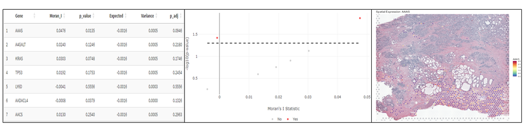

Together, these analyses help bridge quantitative spatial statistics (Moran’s I) with visual intuition (the expression plot). Strong autocorrelation suggests the gene’s expression is non-random and possibly regulated by local microenvironments, cell-cell interactions, or diffusion gradients. This could guide further investigation into the gene’s role in tissue organization or disease. If Moran’I is non-significant, the gene’s expression may be uniformly distributed or driven by cell-intrinsic factors rather than spatial cues.